# Stat400 Project 1

First, the extended example:

```r
setwd("/Users/jeffreymansour/Downloads/P_Data_Extract_From_World_Development_Indicators")
female <- read.csv("female.csv")
is.data.frame(female)
```

```
## [1] TRUE
```

```r
head(female)
```

|  | Series.Name | Series.Code | Country.Name | Country.Code | X1990..YR1990. | X2000..YR2000. | X2013..YR2013. | X2014..YR2014. | X2015..YR2015. | X2016..YR2016. | X2017..YR2017. | X2018..YR2018. | X2019..YR2019. | X2020..YR2020. | X2021..YR2021. | X2022..YR2022. |
| --- | --- | --- | --- | --- | --- | --- | --- | --- | --- | --- | --- | --- | --- | --- | --- | --- |
| 1 | Account ownership at a financial institution or with a mobile-money-service provider, female (% of population ages 15+) | FX.OWN.TOTL.FE.ZS | Afghanistan | AFG | .. | .. | .. | 3.81 | .. | .. | 7.16 | .. | .. | .. | 4.7 | .. |
| 2 | Account ownership at a financial institution or with a mobile-money-service provider, female (% of population ages 15+) | FX.OWN.TOTL.FE.ZS | Albania | ALB | .. | .. | .. | 33.59 | .. | .. | 38.1 | .. | .. | .. | 45.69 | .. |
| 3 | Account ownership at a financial institution or with a mobile-money-service provider, female (% of population ages 15+) | FX.OWN.TOTL.FE.ZS | Algeria | DZA | .. | .. | .. | 40.07 | .. | .. | 29.27 | .. | .. | .. | 31.19 | .. |
| 4 | Account ownership at a financial institution or with a mobile-money-service provider, female (% of population ages 15+) | FX.OWN.TOTL.FE.ZS | American Samoa | ASM | .. | .. | .. | .. | .. | .. | .. | .. | .. | .. | .. | .. |
| 5 | Account ownership at a financial institution or with a mobile-money-service provider, female (% of population ages 15+) | FX.OWN.TOTL.FE.ZS | Andorra | AND | .. | .. | .. | .. | .. | .. | .. | .. | .. | .. | .. | .. |
| 6 | Account ownership at a financial institution or with a mobile-money-service provider, female (% of population ages 15+) | FX.OWN.TOTL.FE.ZS | Angola | AGO | .. | .. | .. | 22.33 | .. | .. | .. | .. | .. | .. | .. | .. |

```r
library(tidyverse)
female <- female %>% filter(Country.Name == "Brazil" | Country.Name == "India" | Country.Name == "United States")
head(female)
```

|  | Series.Name | Series.Code | Country.Name | Country.Code | X1990..YR1990. | X2000..YR2000. | X2013..YR2013. | X2014..YR2014. | X2015..YR2015. | X2016..YR2016. | X2017..YR2017. | X2018..YR2018. | X2019..YR2019. | X2020..YR2020. | X2021..YR2021. | X2022..YR2022. |
| --- | --- | --- | --- | --- | --- | --- | --- | --- | --- | --- | --- | --- | --- | --- | --- | --- |
| 1 | Account ownership at a financial institution or with a mobile-money-service provider, female (% of population ages 15+) | FX.OWN.TOTL.FE.ZS | Brazil | BRA | .. | .. | .. | 64.77 | .. | .. | 67.51 | .. | .. | .. | 80.87 | .. |
| 2 | Account ownership at a financial institution or with a mobile-money-service provider, female (% of population ages 15+) | FX.OWN.TOTL.FE.ZS | India | IND | .. | .. | .. | 43.13 | .. | .. | 76.64 | .. | .. | .. | 77.55 | .. |
| 3 | Account ownership at a financial institution or with a mobile-money-service provider, female (% of population ages 15+) | FX.OWN.TOTL.FE.ZS | United States | USA | .. | .. | .. | 94.8 | .. | .. | 92.69 | .. | .. | .. | 96.79 | .. |

```r
colnames(female)
```

```
##  [1] "Series.Name"    "Series.Code"    "Country.Name"   "Country.Code"
##  [5] "X1990..YR1990." "X2000..YR2000." "X2013..YR2013." "X2014..YR2014."
##  [9] "X2015..YR2015." "X2016..YR2016." "X2017..YR2017." "X2018..YR2018."
## [13] "X2019..YR2019." "X2020..YR2020." "X2021..YR2021." "X2022..YR2022."
```

```r
rel_col <- which(colnames(female)=="Country.Name" | colnames(female)== "X2014..YR2014." | colnames(female)== "X2017..YR2017." | colnames(female) == "X2021..YR2021.")
rel_col
```

```
## [1]  3  8 11 15
```

```r
female <- female[rel_col] %>% rename("2014" = 2, "2017" = 3, "2021" = 4)
head(female)
```

|  | Country.Name | 2014 | 2017 | 2021 |
| --- | --- | --- | --- | --- |
| 1 | Brazil | 64.77 | 67.51 | 80.87 |
| 2 | India | 43.13 | 76.64 | 77.55 |
| 3 | United States | 94.8 | 92.69 | 96.79 |

```r
transpose_f <- data.frame(t(female[-1]))
colnames(transpose_f) <- female[, 1]
head(transpose_f)
```

|  | Brazil | India | United States |
| --- | --- | --- | --- |
| 2014 | 64.77 | 43.13 | 94.8 |
| 2017 | 67.51 | 76.64 | 92.69 |
| 2021 | 80.87 | 77.55 | 96.79 |

```r
print(sapply(transpose_f, class))
```

```
##        Brazil         India United States
##   "character"   "character"   "character"
```

```r
transpose_f$Brazil = as.numeric(transpose_f$Brazil)
transpose_f$India = as.numeric(transpose_f$India)
transpose_f$"United States" = as.numeric(transpose_f$"United States")
head(transpose_f)
```

|  | Brazil | India | United States |
| --- | --- | --- | --- |
| 2014 | 64.77 | 43.13 | 94.80 |
| 2017 | 67.51 | 76.64 | 92.69 |
| 2021 | 80.87 | 77.55 | 96.79 |

```r
summarise_each(transpose_f, list(mean))
```

| Brazil | India | United States |
| --- | --- | --- |
| 71.05 | 65.77333 | 94.76 |

```r
transpose_f %>% summarise(across(c(Brazil, India, "United States"), list(mean=mean, sd=sd)))
```

| Brazil_mean | Brazil_sd | India_mean | India_sd | United States_mean | United States_sd |
| --- | --- | --- | --- | --- | --- |
| 71.05 | 8.614012 | 65.77333 | 19.61498 | 94.76 | 2.050293 |

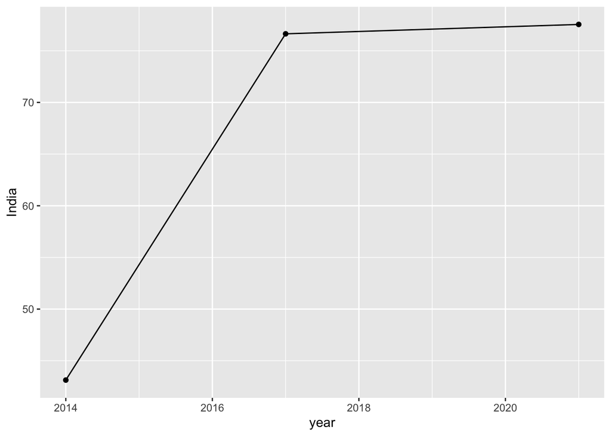

```r
year <- c(2014, 2017,2021)
ggplot(data=transpose_f, aes(x=year, y=India, group=1)) + geom_line() + geom_point()
```

```r
setwd("/Users/jeffreymansour/Downloads/P_Data_Extract_From_World_Development_Indicators-2")
male <- read.csv(file = "Male.csv")
male <- male %>% filter(Country.Name == "Brazil" | Country.Name == "India" | Country.Name == "United States")
male <- male[rel_col] %>% rename("2014" = 2, "2017" = 3, "2021" = 4)
transpose_m <- data.frame(t(male[-1]))
colnames(transpose_m) <- male[, 1]
transpose_m$Brazil = as.numeric(as.character(transpose_m$Brazil))
transpose_m$India = as.numeric(as.character(transpose_m$India))
transpose_m$"United States" = as.numeric(as.character((transpose_m$"United States")))
head(transpose_m)
```

|  | Brazil | India | United States |
| --- | --- | --- | --- |
| 2014 | 71.69 | 62.76 | 92.36 |
| 2017 | 72.85 | 83.01 | 93.57 |
| 2021 | 87.05 | 77.51 | 93.09 |

```r
transpose_m <- rename(transpose_m, "Brazil_m" = 1, "India_m" = 2, "United_States_m" = 3)
head(transpose_m)
```

|  | Brazil_m | India_m | United_States_m |
| --- | --- | --- | --- |
| 2014 | 71.69 | 62.76 | 92.36 |
| 2017 | 72.85 | 83.01 | 93.57 |
| 2021 | 87.05 | 77.51 | 93.09 |

```r
transpose_m <- rownames_to_column(transpose_m, var="Year")
transpose_f <- rownames_to_column(transpose_f, var="Year")
acct_owner_by_gender <- merge(x = transpose_m, y = transpose_f, by = "Year", all.x = TRUE)
acct_owner_by_gender <- rename(acct_owner_by_gender, "United_States" = 7)
head(acct_owner_by_gender)
```

|  | Year | Brazil_m | India_m | United_States_m | Brazil | India | United_States |
| --- | --- | --- | --- | --- | --- | --- | --- |
| 1 | 2014 | 71.69 | 62.76 | 92.36 | 64.77 | 43.13 | 94.80 |
| 2 | 2017 | 72.85 | 83.01 | 93.57 | 67.51 | 76.64 | 92.69 |
| 3 | 2021 | 87.05 | 77.51 | 93.09 | 80.87 | 77.55 | 96.79 |

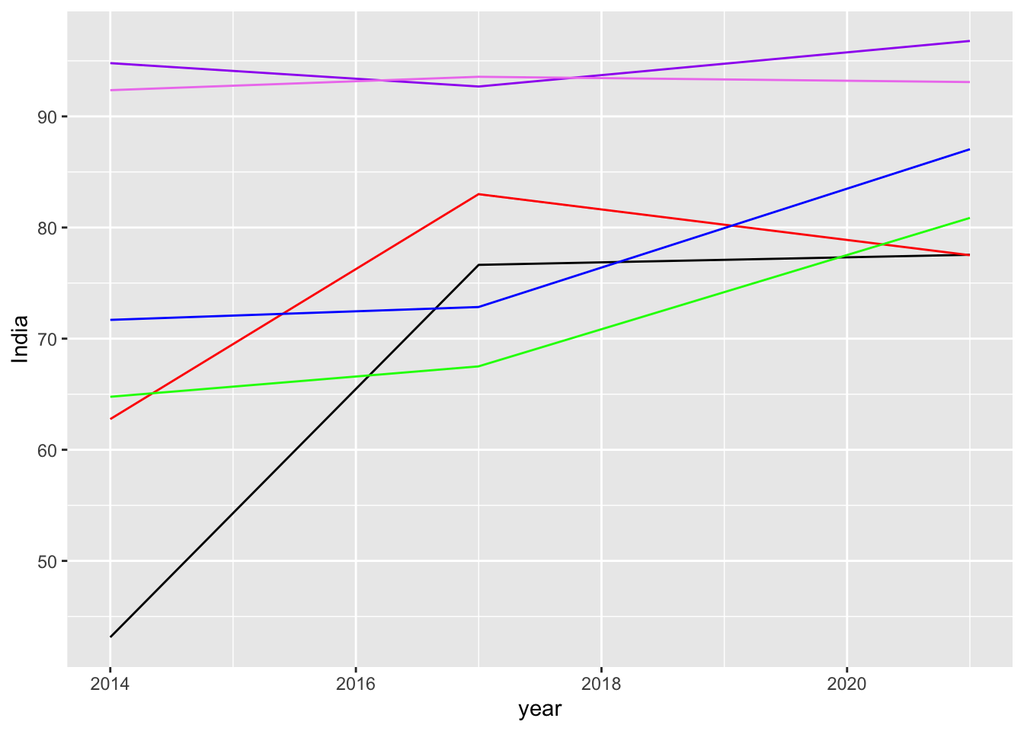

```r
gfg_plot <- ggplot(acct_owner_by_gender, aes(x=year)) +
    geom_line(aes(y = India), color = "black") +
    geom_line(aes(y = India_m), color = "red") +
    geom_line(aes(y = Brazil), color = "green") +
    geom_line(aes(y = Brazil_m), color = "blue") +
    geom_line(aes(y = United_States), color = "purple") +
    geom_line(aes(y = United_States_m), color = "violet")
gfg_plot
```

Project Starts Here

1. (Cleaning up the final plot) The final plot is somewhat misleading: the y-axis is titled “India”. Write down the code that will change it to percentage ownership.

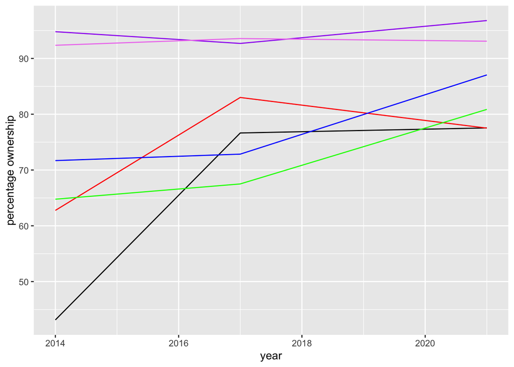

```r
gfg_plot <- gfg_plot + labs(y="percentage ownership")
gfg_plot
```

2. (Drawing Conclusions) After drawing the plot that includes how percentages change over time, use this to draw some (fairly basic) conclusions on the how the ownership percentages have been changed. For example, you can discuss whether males have more account ownership than females and whether the data suggests that account ownership percentages are on the rise.

Considering Brazil and India have a significantly higher percentage ownership in 2021 than they did in 2014 for both genders, the data suggests account ownership percentages are on the rise in these countries. In the US, however, percentage ownership has appeared to stay fairly steady for both genders. In Brazil, the male percentage ownership is significantly greater than the female percentage ownership from 2014 to 2021, suggesting males have had greater percentage ownership than females consistently in the country. This trend was true for India as well until 2021, when the male percentage ownership was about equal to the female percentage ownership. In the US, the male percentage ownership has gone both slightly above and slightly below the female percentage ownership over time, suggesting there is not a major difference in male and female percentage ownership in the US. Comparing the countries to one another, it appears the US has had significantly higher percentage ownership numbers than Brazil and India for both genders, but Brazil and India appear to be approaching the US numbers while the US numbers stay relatively constant.

3. (Cherry Picking) Is it possible to say that account percentages have been increasing if you disregard a certain year? Does this change if you focus on a particular country and gender combinations?

It is possible to say that account percentages have been increasing if we disregard a certain year from the data, as we could still measure the difference in percentage ownership between the two years of data that are not disregarded. For instance, if we disregarded the 2017 data, we could still see that percentage ownership numbers were higher in 2021 than 2014 for both genders in each of the countries, meaning percentage ownership increased in these countries over this period. All we would lose is the details of how the percentage ownership numbers changed during the time period (i.e. for Indian males, we would only see that percentage ownership increased overall from 2014 to 2021, and we wouldn’t see that it increased greatly from 2014 to 2017 then actually decreased from 2017 to 2021). However, if we only look at a particular country and gender combination, disregarding a certain year might lead us to make a different assessment of whether percentage ownership increased. For example, if we only looked at the data for Indian males and disregarded the 2014 data, we would see that Indian male percentage ownership was lower in 2021 than in 2017, so we would not be able to say percentage ownership increased.

4. (Summarzing the data yourself) Do a similar analysis using the csv files….You should analyze exactly five countries. You are free to pick the countries but your choices should not include the United States, India nor Brazil. After a visual representation of the data is made, you should have a paragraph or two summarizing your conclusions. The summary should be about the length of half a page and no longer than a page.

```r
setwd("/Users/jeffreymansour/Downloads/P_Data_Extract_From_World_Development_Indicators-3")
primary <- read.csv(file = "Primary.csv")
primary <- primary %>% filter(Country.Name == "Bangladesh" | Country.Name == "Bolivia" | Country.Name == "Italy" | Country.Name == "Tanzania" | Country.Name == "Saudi Arabia")
primary <- primary[rel_col] %>% rename("2014" = 2, "2017" = 3, "2021" = 4)
transpose_p <- data.frame(t(primary[-1]))
colnames(transpose_p) <- primary[, 1]
transpose_p$Bangladesh = as.numeric(transpose_p$Bangladesh)
transpose_p$Bolivia = as.numeric(transpose_p$Bolivia)
transpose_p$Italy = as.numeric(transpose_p$Italy)
transpose_p$Tanzania = as.numeric(transpose_p$Tanzania)
transpose_p$"Saudi Arabia" = as.numeric(transpose_p$"Saudi Arabia")
setwd("/Users/jeffreymansour/Downloads/P_Data_Extract_From_World_Development_Indicators-4")
secondary <- read.csv(file = "Secondary.csv")
secondary <- secondary %>% filter(Country.Name == "Bangladesh" | Country.Name == "Bolivia" | Country.Name == "Italy" | Country.Name == "Tanzania" | Country.Name == "Saudi Arabia")
secondary <- secondary[rel_col] %>% rename("2014" = 2, "2017" = 3, "2021" = 4)
transpose_s <- data.frame(t(secondary[-1]))
colnames(transpose_s) <- secondary[, 1]
transpose_s$Bangladesh = as.numeric(transpose_s$Bangladesh)
transpose_s$Bolivia = as.numeric(transpose_s$Bolivia)
transpose_s$Italy = as.numeric(transpose_s$Italy)
transpose_s$Tanzania = as.numeric(transpose_s$Tanzania)
transpose_s$"Saudi Arabia" = as.numeric(transpose_s$"Saudi Arabia")
head(primary)
```

|  | Country.Name | 2014 | 2017 | 2021 |
| --- | --- | --- | --- | --- |
| 1 | Bangladesh | 24.9 | 39.84 | 46.57 |
| 2 | Bolivia | 19.96 | 43.05 | 55.39 |
| 3 | Italy | 79.48 | 92.01 | 97.25 |
| 4 | Saudi Arabia | 64.16 | 65.02 | 76.8 |
| 5 | Tanzania | 32.63 | 41.02 | 46.7 |

```r
head(secondary)
```

|  | Country.Name | 2014 | 2017 | 2021 |
| --- | --- | --- | --- | --- |
| 1 | Bangladesh | 37.21 | 57.23 | 56.63 |
| 2 | Bolivia | 48.16 | 60.69 | 75.41 |
| 3 | Italy | 94.58 | 96.31 | 97.32 |
| 4 | Saudi Arabia | 70.87 | 72.65 | 74.22 |
| 5 | Tanzania | 68.11 | 66.94 | 73.5 |

```r
transpose_p <- rename(transpose_p, "Bangladesh_p" = 1, "Bolivia_p" = 2, "Italy_p" = 3, "Saudi_Arabia_p" = 4, "Tanzania_p" = 5)
transpose_s <- rename(transpose_s, "Bangladesh_s" = 1, "Bolivia_s" = 2, "Italy_s" = 3, "Saudi_Arabia_s" = 4, "Tanzania_s" = 5)
transpose_p <- rownames_to_column(transpose_p, var="Year")
transpose_s <- rownames_to_column(transpose_s, var="Year")
acct_owner_by_education <- merge(x = transpose_p, y = transpose_s, by = "Year", all.x = TRUE)
head(acct_owner_by_education)
```

|  | Year | Bangladesh_p | Bolivia_p | Italy_p | Saudi_Arabia_p | Tanzania_p | Bangladesh_s | Bolivia_s | Italy_s | Saudi_Arabia_s | Tanzania_s |
| --- | --- | --- | --- | --- | --- | --- | --- | --- | --- | --- | --- |
| 1 | 2014 | 24.90 | 19.96 | 79.48 | 64.16 | 32.63 | 37.21 | 48.16 | 94.58 | 70.87 | 68.11 |
| 2 | 2017 | 39.84 | 43.05 | 92.01 | 65.02 | 41.02 | 57.23 | 60.69 | 96.31 | 72.65 | 66.94 |
| 3 | 2021 | 46.57 | 55.39 | 97.25 | 76.80 | 46.70 | 56.63 | 75.41 | 97.32 | 74.22 | 73.50 |

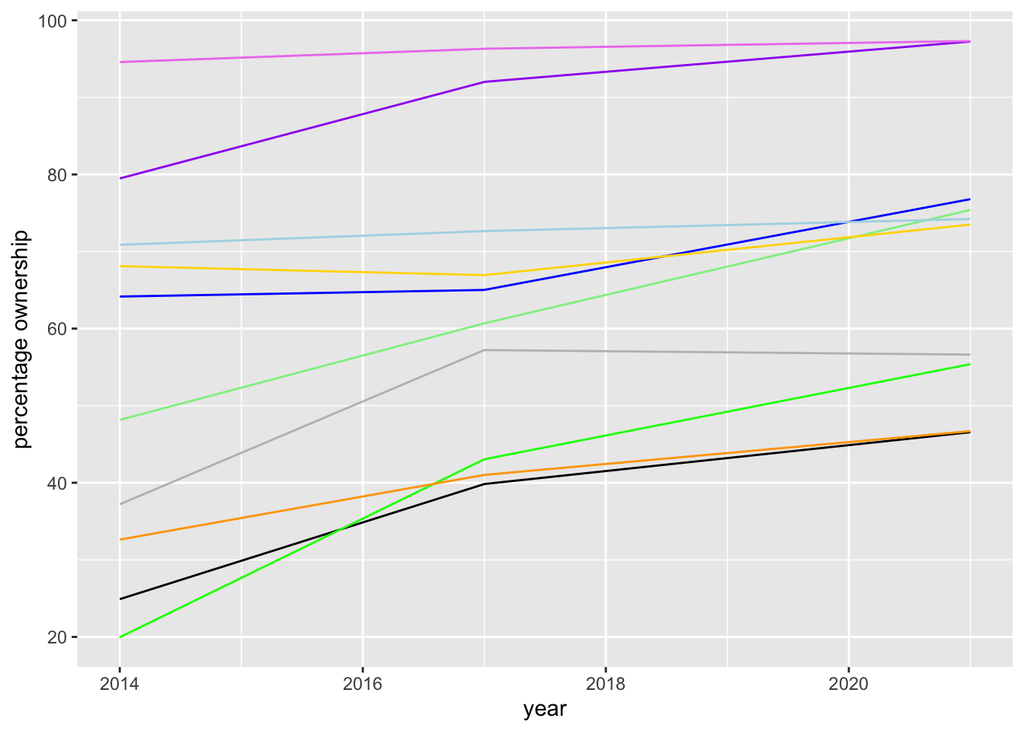

```r
gfg_plot2 <- ggplot(acct_owner_by_education, aes(x=year)) +
    geom_line(aes(y = Bangladesh_p), color = "black") +
    geom_line(aes(y = Bangladesh_s), color = "gray") +
    geom_line(aes(y = Bolivia_p), color = "green") +
    geom_line(aes(y = Bolivia_s), color = "lightgreen") +
    geom_line(aes(y = Italy_p), color = "purple") +
    geom_line(aes(y = Italy_s), color = "violet") +
    geom_line(aes(y = Saudi_Arabia_p), color = "blue") +
    geom_line(aes(y = Saudi_Arabia_s), color = "lightblue") +
    geom_line(aes(y = Tanzania_p), color = "orange") +
    geom_line(aes(y = Tanzania_s), color = "gold")
gfg_plot2 <- gfg_plot2 + labs(y="percentage ownership")
gfg_plot2
```

Conclusions:

Based on the graphs, it appears financial account ownership percentage increased for both those with primary education or less and those with secondary education or more in all five countries–Bangladesh, Bolivia, Italy, Saudi Arabia and Tanzania–between 2014 and 2021. The fact that all five of these countries experienced considerable increases in percentage ownership could suggest there was a global increase in percentage ownership over this span, but we’d likely need a sample of countries larger than five to be confident in this generalization. Additionally, there were some clear differences in overall account percentage ownership between the countries. Italy had significantly higher percentage ownership than the other four countries for both those with secondary education or higher and those with primary education or lower. Looking at percentage ownership for those with secondary education or more, Italy was followed by Saudi Arabia, Tanzania, Bolivia then Bangladesh. For those with primary education or less, Italy was followed by Saudi Arabia, but then the numbers were fairly even between Bolivia, Tanzania and Bangladesh over the time period.